# Cyclospora Outbreak in Texas

Robin Choudhury

2017-09-21

## Cyclospora

Cyclosporiasis is an intestinal sickness caused by the coccidian parasite *Cyclospora cayetanensis*. An outbreak in 2017 seemingly from Mexican cilantro has affected many people, and the Texas public health board and CDC put out some of the data publically. I wanted to go through this data, make choropleth plots for the counties affected (because I am unfamiliar with Texan counties) and plot out the data. This was also prompted because I ate some cilantro and immediately went into hypochondriac mode. You can find the code for this post at https://github.com/robchoudhury/TexasCyclospora

Lets get into it!

## Epi Curves in Texas

They recorded the number of cases over time in Texas.

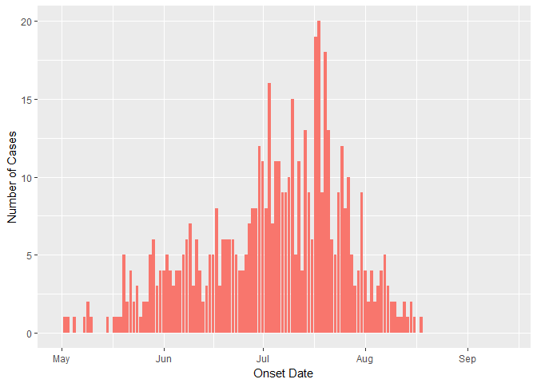

```r
ggplot(timeline, aes(`Onset Date`, `Number of Cases`, fill="red"))+
  geom_bar(stat = "identity")+
  theme(legend.position = "none")
```

```r
ggsave(filename = "timeline.png")
```

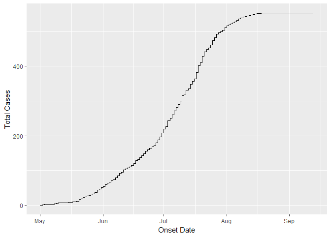

```r
ggplot(timeline, aes(`Onset Date`, cumsum))+
  geom_step()+
  ylab("Total Cases")
```

```r
ggsave(filename = "totalcases.png")
```

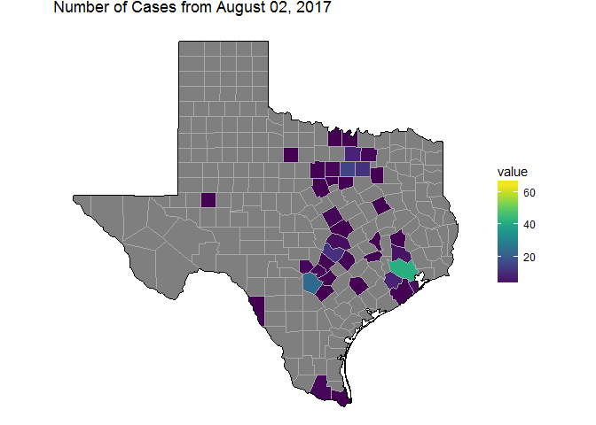

```r
Aug02= Aug02 %>%
  select(.,c(.data$region,.data$cases))
colnames(Aug02)<-c("region","value")
Aug02=rbind(Aug02, c(2020, max(test.1$cases))) #region 2020 is the eastern Aleutean Islands, this (hopefully?) tricks ggplot into plotting a fake max


Aug22= Aug22 %>%
  select(.,c(.data$region,.data$cases))
colnames(Aug22)<-c("region","value")
Aug22=rbind(Aug22, c(2020, max(test.1$cases)))


choro02=county_choropleth(Aug02,
                  num_colors = 1,
                  legend = "Year",
                  state_zoom = c("texas"))

choro02 = choro02+ scale_fill_viridis(limits = range(Aug02$value))+ggtitle("Number of Cases from August 02, 2017");choro02
```

```r
ggsave(filename = "Aug02.png")


choro22=county_choropleth(Aug22,
                  num_colors = 1,
                  legend = "Year",
                  state_zoom = c("texas"))

choro22 = choro22+ scale_fill_viridis()+ggtitle("Number of Cases from August 22, 2017");choro22
```

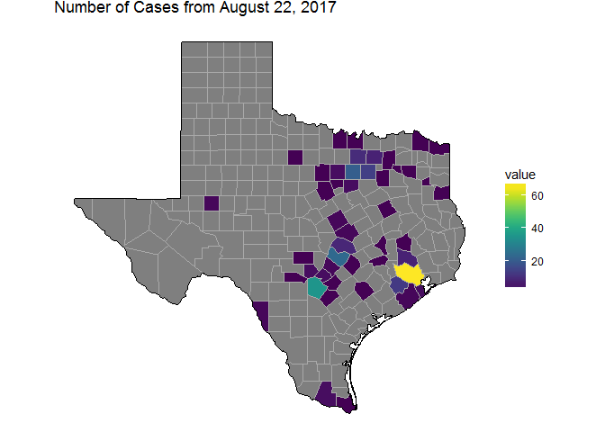

```r
ggsave(filename = "Aug22.png")
```

## Now the Rest of the US

```r
test2.1= us %>%
  select(.,c(.data$state.name,.data$infected))
colnames(test2.1)<-c("region","value")

choroUS=state_choropleth(test2.1,
                  num_colors = 1,
                  legend = "Year")
choroUS = choroUS+ scale_fill_viridis()+ggtitle("US Cyclospora Outbreak as of 2017-09-13");choroUS
```

[output not shown]

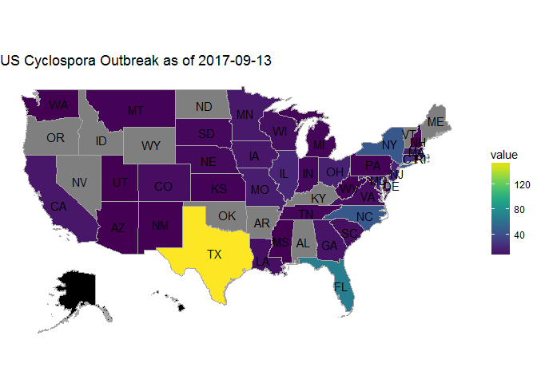

```r
ggsave(filename = "USSep13.png")
```

So while Texas bore the brunt of the epidemic, other states definitely were also affected. It should be noted that NYC had almost 3 times as many cases as the rest of NY state, but I couldnt represent that on the graph.